# House Prices - EDA and Models for Kaggle

## Download the data:

```python
!kaggle competitions download -c house-prices-advanced-regression-techniques
```

```python
!mkdir data
!unzip house-prices-advanced-regression-techniques.zip -d data
```

## Setup

```python
import pandas as pd
import numpy as np
import matplotlib.pyplot as plt
import seaborn as sns
from scipy.stats import norm
from scipy import stats
from datetime import datetime
from scipy.stats import pearsonr
from sklearn.preprocessing import LabelEncoder


# Since the dataset has a large number of features, it's best to let Pandas display all the columns of the dataframe
pd.options.display.max_columns = None
# Turn off Future Warnings
import warnings
warnings.simplefilter(action='ignore', category=FutureWarning)
```

## Read the data

```python
# Read the training data
train_df = pd.read_csv("data/train.csv")
# Read the test data
test_df = pd.read_csv("data/test.csv")
train_df.head()
```

|  | Id | MSSubClass | MSZoning | LotFrontage | LotArea | Street | Alley | LotShape | LandContour | Utilities | LotConfig | LandSlope | Neighborhood | Condition1 | Condition2 | BldgType | HouseStyle | OverallQual | OverallCond | YearBuilt | YearRemodAdd | RoofStyle | RoofMatl | Exterior1st | Exterior2nd | MasVnrType | MasVnrArea | ExterQual | ExterCond | … |
| --- | --- | --- | --- | --- | --- | --- | --- | --- | --- | --- | --- | --- | --- | --- | --- | --- | --- | --- | --- | --- | --- | --- | --- | --- | --- | --- | --- | --- | --- | --- |
| 0 | 1 | 60 | RL | 65.0 | 8450 | Pave | NaN | Reg | Lvl | AllPub | Inside | Gtl | CollgCr | Norm | Norm | 1Fam | 2Story | 7 | 5 | 2003 | 2003 | Gable | CompShg | VinylSd | VinylSd | BrkFace | 196.0 | Gd | TA | … |
| 1 | 2 | 20 | RL | 80.0 | 9600 | Pave | NaN | Reg | Lvl | AllPub | FR2 | Gtl | Veenker | Feedr | Norm | 1Fam | 1Story | 6 | 8 | 1976 | 1976 | Gable | CompShg | MetalSd | MetalSd | None | 0.0 | TA | TA | … |
| 2 | 3 | 60 | RL | 68.0 | 11250 | Pave | NaN | IR1 | Lvl | AllPub | Inside | Gtl | CollgCr | Norm | Norm | 1Fam | 2Story | 7 | 5 | 2001 | 2002 | Gable | CompShg | VinylSd | VinylSd | BrkFace | 162.0 | Gd | TA | … |
| 3 | 4 | 70 | RL | 60.0 | 9550 | Pave | NaN | IR1 | Lvl | AllPub | Corner | Gtl | Crawfor | Norm | Norm | 1Fam | 2Story | 7 | 5 | 1915 | 1970 | Gable | CompShg | Wd Sdng | Wd Shng | None | 0.0 | TA | TA | … |
| 4 | 5 | 60 | RL | 84.0 | 14260 | Pave | NaN | IR1 | Lvl | AllPub | FR2 | Gtl | NoRidge | Norm | Norm | 1Fam | 2Story | 8 | 5 | 2000 | 2000 | Gable | CompShg | VinylSd | VinylSd | BrkFace | 350.0 | Gd | TA | … |

## Reading the description file provided by Kaggle.

Since our datasets came with a description file, it's best to review that quickly and get a sense of the features. This will help guide the analysis.

```python
desc = open("data/data_description.txt")
txt = desc.read()
print(txt)
desc.close()
```

```
MSSubClass: Identifies the type of dwelling involved in the sale.

        20	1-STORY 1946 & NEWER ALL STYLES
        30	1-STORY 1945 & OLDER
        40	1-STORY W/FINISHED ATTIC ALL AGES
        45	1-1/2 STORY - UNFINISHED ALL AGES
        50	1-1/2 STORY FINISHED ALL AGES
        60	2-STORY 1946 & NEWER
        70	2-STORY 1945 & OLDER
        75	2-1/2 STORY ALL AGES
        80	SPLIT OR MULTI-LEVEL
        85	SPLIT FOYER
        90	DUPLEX - ALL STYLES AND AGES
       120	1-STORY PUD (Planned Unit Development) - 1946 & NEWER
       150	1-1/2 STORY PUD - ALL AGES
       160	2-STORY PUD - 1946 & NEWER
       180	PUD - MULTILEVEL - INCL SPLIT LEV/FOYER
       190	2 FAMILY CONVERSION - ALL STYLES AND AGES

MSZoning: Identifies the general zoning classification of the sale.

       A	Agriculture
       C	Commercial
       FV	Floating Village Residential
       I	Industrial
       RH	Residential High Density
       RL	Residential Low Density
       RP	Residential Low Density Park
       RM	Residential Medium Density

LotFrontage: Linear feet of street connected to property

LotArea: Lot size in square feet

Street: Type of road access to property

       Grvl	Gravel
       Pave	Paved

Alley: Type of alley access to property
```

[output cut: 468 more lines]

```
       COD	Court Officer Deed/Estate
       Con	Contract 15% Down payment regular terms
       ConLw	Contract Low Down payment and low interest
       ConLI	Contract Low Interest
       ConLD	Contract Low Down
       Oth	Other

SaleCondition: Condition of sale

       Normal	Normal Sale
       Abnorml	Abnormal Sale -  trade, foreclosure, short sale
       AdjLand	Adjoining Land Purchase
       Alloca	Allocation - two linked properties with separate deeds, typically condo with a garage unit
       Family	Sale between family members
       Partial	Home was not completed when last assessed (associated with New Homes)
```

```python
# Saving the the ID column for both train and test
train_Id = train_df['Id']
test_Id = test_df['Id']
```

```python
print("There are {} rows in the training dataframe".format(train_df.shape[0]))
print("There are {} features in the training dataframe".format(train_df.shape[-1]))
print("There are {} rows in the testing dataframe".format(test_df.shape[0]))
```

```
There are 1460 rows in the training dataframe
There are 81 features in the training dataframe
There are 1459 rows in the testing dataframe
```

```python
train_df.describe()
```

|  | Id | MSSubClass | LotFrontage | LotArea | OverallQual | OverallCond | YearBuilt | YearRemodAdd | MasVnrArea | BsmtFinSF1 | BsmtFinSF2 | BsmtUnfSF | TotalBsmtSF | 1stFlrSF | 2ndFlrSF | LowQualFinSF | GrLivArea | BsmtFullBath | BsmtHalfBath | FullBath | HalfBath | BedroomAbvGr | KitchenAbvGr | TotRmsAbvGrd | Fireplaces | GarageYrBlt | GarageCars | GarageArea | WoodDeckSF | … |
| --- | --- | --- | --- | --- | --- | --- | --- | --- | --- | --- | --- | --- | --- | --- | --- | --- | --- | --- | --- | --- | --- | --- | --- | --- | --- | --- | --- | --- | --- | --- |
| count | 1460.000000 | 1460.000000 | 1201.000000 | 1460.000000 | 1460.000000 | 1460.000000 | 1460.000000 | 1460.000000 | 1452.000000 | 1460.000000 | 1460.000000 | 1460.000000 | 1460.000000 | 1460.000000 | 1460.000000 | 1460.000000 | 1460.000000 | 1460.000000 | 1460.000000 | 1460.000000 | 1460.000000 | 1460.000000 | 1460.000000 | 1460.000000 | 1460.000000 | 1379.000000 | 1460.000000 | 1460.000000 | 1460.000000 | … |
| mean | 730.500000 | 56.897260 | 70.049958 | 10516.828082 | 6.099315 | 5.575342 | 1971.267808 | 1984.865753 | 103.685262 | 443.639726 | 46.549315 | 567.240411 | 1057.429452 | 1162.626712 | 346.992466 | 5.844521 | 1515.463699 | 0.425342 | 0.057534 | 1.565068 | 0.382877 | 2.866438 | 1.046575 | 6.517808 | 0.613014 | 1978.506164 | 1.767123 | 472.980137 | 94.244521 | … |
| std | 421.610009 | 42.300571 | 24.284752 | 9981.264932 | 1.382997 | 1.112799 | 30.202904 | 20.645407 | 181.066207 | 456.098091 | 161.319273 | 441.866955 | 438.705324 | 386.587738 | 436.528436 | 48.623081 | 525.480383 | 0.518911 | 0.238753 | 0.550916 | 0.502885 | 0.815778 | 0.220338 | 1.625393 | 0.644666 | 24.689725 | 0.747315 | 213.804841 | 125.338794 | … |
| min | 1.000000 | 20.000000 | 21.000000 | 1300.000000 | 1.000000 | 1.000000 | 1872.000000 | 1950.000000 | 0.000000 | 0.000000 | 0.000000 | 0.000000 | 0.000000 | 334.000000 | 0.000000 | 0.000000 | 334.000000 | 0.000000 | 0.000000 | 0.000000 | 0.000000 | 0.000000 | 0.000000 | 2.000000 | 0.000000 | 1900.000000 | 0.000000 | 0.000000 | 0.000000 | … |
| 25% | 365.750000 | 20.000000 | 59.000000 | 7553.500000 | 5.000000 | 5.000000 | 1954.000000 | 1967.000000 | 0.000000 | 0.000000 | 0.000000 | 223.000000 | 795.750000 | 882.000000 | 0.000000 | 0.000000 | 1129.500000 | 0.000000 | 0.000000 | 1.000000 | 0.000000 | 2.000000 | 1.000000 | 5.000000 | 0.000000 | 1961.000000 | 1.000000 | 334.500000 | 0.000000 | … |
| 50% | 730.500000 | 50.000000 | 69.000000 | 9478.500000 | 6.000000 | 5.000000 | 1973.000000 | 1994.000000 | 0.000000 | 383.500000 | 0.000000 | 477.500000 | 991.500000 | 1087.000000 | 0.000000 | 0.000000 | 1464.000000 | 0.000000 | 0.000000 | 2.000000 | 0.000000 | 3.000000 | 1.000000 | 6.000000 | 1.000000 | 1980.000000 | 2.000000 | 480.000000 | 0.000000 | … |
| 75% | 1095.250000 | 70.000000 | 80.000000 | 11601.500000 | 7.000000 | 6.000000 | 2000.000000 | 2004.000000 | 166.000000 | 712.250000 | 0.000000 | 808.000000 | 1298.250000 | 1391.250000 | 728.000000 | 0.000000 | 1776.750000 | 1.000000 | 0.000000 | 2.000000 | 1.000000 | 3.000000 | 1.000000 | 7.000000 | 1.000000 | 2002.000000 | 2.000000 | 576.000000 | 168.000000 | … |
| max | 1460.000000 | 190.000000 | 313.000000 | 215245.000000 | 10.000000 | 9.000000 | 2010.000000 | 2010.000000 | 1600.000000 | 5644.000000 | 1474.000000 | 2336.000000 | 6110.000000 | 4692.000000 | 2065.000000 | 572.000000 | 5642.000000 | 3.000000 | 2.000000 | 3.000000 | 2.000000 | 8.000000 | 3.000000 | 14.000000 | 3.000000 | 2010.000000 | 4.000000 | 1418.000000 | 857.000000 | … |

```python
train_df.info()
```

```
<class 'pandas.core.frame.DataFrame'>
RangeIndex: 1460 entries, 0 to 1459
Data columns (total 81 columns):
Id               1460 non-null int64
MSSubClass       1460 non-null int64
MSZoning         1460 non-null object
LotFrontage      1201 non-null float64
LotArea          1460 non-null int64
Street           1460 non-null object
Alley            91 non-null object
LotShape         1460 non-null object
LandContour      1460 non-null object
Utilities        1460 non-null object
LotConfig        1460 non-null object
LandSlope        1460 non-null object
Neighborhood     1460 non-null object
Condition1       1460 non-null object
Condition2       1460 non-null object
BldgType         1460 non-null object
HouseStyle       1460 non-null object
OverallQual      1460 non-null int64
OverallCond      1460 non-null int64
YearBuilt        1460 non-null int64
YearRemodAdd     1460 non-null int64
RoofStyle        1460 non-null object
RoofMatl         1460 non-null object
Exterior1st      1460 non-null object
Exterior2nd      1460 non-null object
MasVnrType       1452 non-null object
MasVnrArea       1452 non-null float64
ExterQual        1460 non-null object
ExterCond        1460 non-null object
Foundation       1460 non-null object
BsmtQual         1423 non-null object
BsmtCond         1423 non-null object
BsmtExposure     1422 non-null object
BsmtFinType1     1423 non-null object
BsmtFinSF1       1460 non-null int64
BsmtFinType2     1422 non-null object
BsmtFinSF2       1460 non-null int64
```

[output cut: 31 more lines]

```
EnclosedPorch    1460 non-null int64
3SsnPorch        1460 non-null int64
ScreenPorch      1460 non-null int64
PoolArea         1460 non-null int64
PoolQC           7 non-null object
Fence            281 non-null object
MiscFeature      54 non-null object
MiscVal          1460 non-null int64
MoSold           1460 non-null int64
YrSold           1460 non-null int64
SaleType         1460 non-null object
SaleCondition    1460 non-null object
SalePrice        1460 non-null int64
dtypes: float64(3), int64(35), object(43)
memory usage: 924.0+ KB
```

#### Quantatitive Variables:

```python
quant_feat = list(train_df.dtypes[train_df.dtypes != "object"].index)
quant_feat
```

```
['Id',
 'MSSubClass',
 'LotFrontage',
 'LotArea',
 'OverallQual',
 'OverallCond',
 'YearBuilt',
 'YearRemodAdd',
 'MasVnrArea',
 'BsmtFinSF1',
 'BsmtFinSF2',
 'BsmtUnfSF',
 'TotalBsmtSF',
 '1stFlrSF',
 '2ndFlrSF',
 'LowQualFinSF',
 'GrLivArea',
 'BsmtFullBath',
 'BsmtHalfBath',
 'FullBath',
 'HalfBath',
 'BedroomAbvGr',
 'KitchenAbvGr',
 'TotRmsAbvGrd',
 'Fireplaces',
 'GarageYrBlt',
 'GarageCars',
 'GarageArea',
 'WoodDeckSF',
 'OpenPorchSF',
 'EnclosedPorch',
 '3SsnPorch',
 'ScreenPorch',
 'PoolArea',
 'MiscVal',
 'MoSold',
 'YrSold',
 'SalePrice']
```

#### Qualatative Variables:

```python
qual_feat = list(train_df.dtypes[train_df.dtypes == "object"].index)
qual_feat
```

```
['MSZoning',
 'Street',
 'Alley',
 'LotShape',
 'LandContour',
 'Utilities',
 'LotConfig',
 'LandSlope',
 'Neighborhood',
 'Condition1',
 'Condition2',
 'BldgType',
 'HouseStyle',
 'RoofStyle',
 'RoofMatl',
 'Exterior1st',
 'Exterior2nd',
 'MasVnrType',
 'ExterQual',
 'ExterCond',
 'Foundation',
 'BsmtQual',
 'BsmtCond',
 'BsmtExposure',
 'BsmtFinType1',
 'BsmtFinType2',
 'Heating',
 'HeatingQC',
 'CentralAir',
 'Electrical',
 'KitchenQual',
 'Functional',
 'FireplaceQu',
 'GarageType',
 'GarageFinish',
 'GarageQual',
 'GarageCond',
 'PavedDrive',
 'PoolQC',
 'Fence',
 'MiscFeature',
 'SaleType',
 'SaleCondition']
```

### Target Variable:

In this section, I am creating a helper function that will help visualize the distribution of features.

```python
def draw_distribution(df, col, **options):
    """
    This function helps draw a distribution plot for the desired colum.
    Input args:
    1. df : Dataframe that we want to pick the column from.
    2. col : Column of the dataframe that we want to display.
    3. options:
        a. kde : optional, boolian - Whether to plot a gaussian kernel density estimate.
        b. fit : An object with `fit` method, returning a tuple that can be passed to a `pdf` method a
        positional arguments following a grid of values to evaluate the pdf on.
    """
    plt.figure(figsize=(12,10))
    plt.ylabel("Frequency")
    plt.title("{} Distribution".format(col))
    if options.get("kde")==True:
        sns.distplot(df[col], kde=True, color="#2b7bba");
    if options.get("fit")== "norm":
        (mu, sigma) = norm.fit(df[col])
        sns.distplot(df[col], fit=norm, color="#2b7bba");
        plt.legend(["Normal dist. ($\mu=$ {:.2f} and $\sigma=$ {:.2f} )".format(mu, sigma)],
                  loc='best');

    if (options.get("fit")== "norm") & (options.get("kde")==True):
        sns.distplot(df[col], fit=norm, kde=True, color="#2b7bba");
    else:
        sns.distplot(df[col], color="#2b7bba");
```

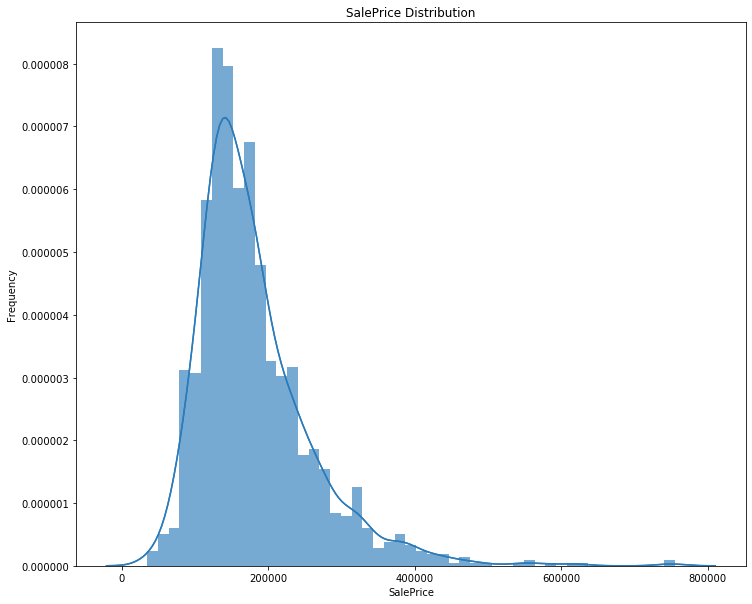

```python
# Let's plot a distribution plot for the target variable column and see how the prices are distributed.
draw_distribution(train_df, "SalePrice", kde=True)
```

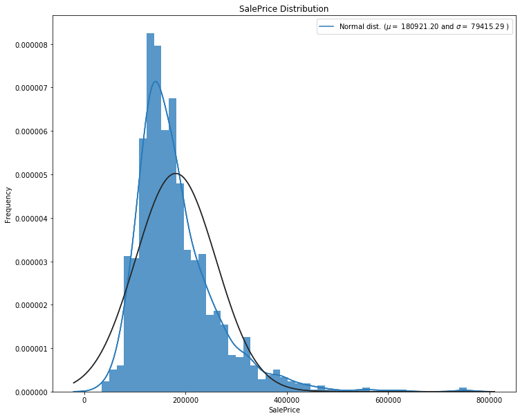

```python
draw_distribution(train_df, "SalePrice",fit="norm", kde=True)
```

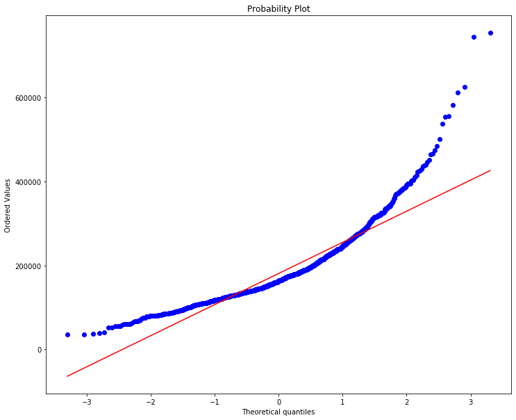

```python
## QQ Plot
fig  = plt.figure(figsize=(12,10))
stats.probplot(train_df["SalePrice"], plot=plt)
plt.show();
```

```python
train_df["SalePrice"].describe()
```

```
count      1460.000000
mean     180921.195890
std       79442.502883
min       34900.000000
25%      129975.000000
50%      163000.000000
75%      214000.000000
max      755000.000000
Name: SalePrice, dtype: float64
```

As we can see, most of the house prices are below the 75 percentile. One way to fix this by using a logarithmic scale.

#### Log Transformation of the target variable

```python
df_scaled = train_df.copy()
#I am usin log1p  function from np which  applies log(1+x) to all elements of the column
df_scaled["SalePrice"] =  np.log1p(train_df["SalePrice"])
```

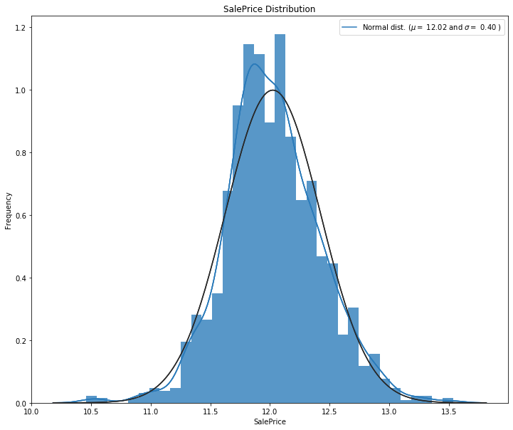

```python
# Plotting the
draw_distribution(df_scaled, "SalePrice",fit="norm", kde=True)
```

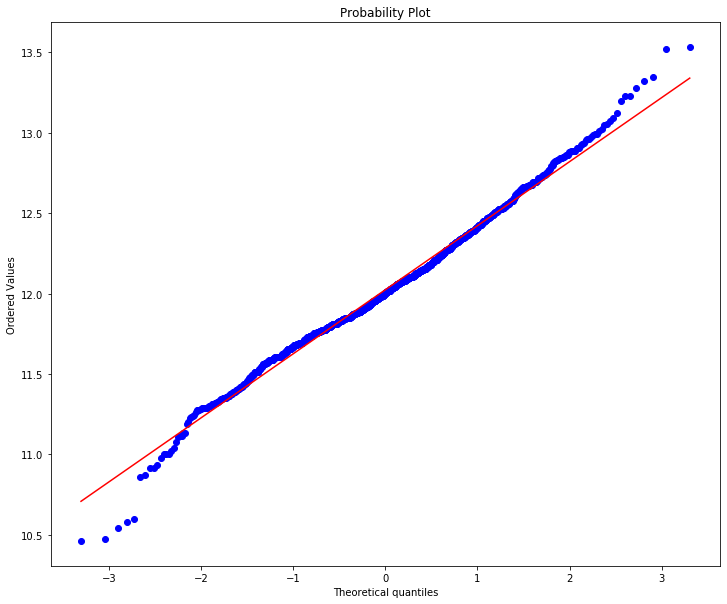

```python
## QQ Plot
fig  = plt.figure(figsize=(12,10))
stats.probplot(df_scaled["SalePrice"], plot=plt)
plt.show();
```

### Missing Values:

In this section, I am going to look into the missing values and come up with the strategies that could help fix those. It's recommended to see if the missing values are random or they an underlying pattern.

```python
# Counting the missing values per feature and picking the top 25
missing_values = df_scaled.isnull().sum().sort_values(ascending=False)[:25]
# Calculating the missing ratio and picking the top 25
ratio = ((df_scaled.isnull().sum()/df_scaled.isnull().count())*100).sort_values(ascending=False)[:25]
missing_data = pd.concat([missing_values, ratio], axis=1, keys=['Total Missing', 'Percent'])
missing_data.head(20)
```

|  | Total Missing | Percent |
| --- | --- | --- |
| PoolQC | 1453 | 99.520548 |
| MiscFeature | 1406 | 96.301370 |
| Alley | 1369 | 93.767123 |
| Fence | 1179 | 80.753425 |
| FireplaceQu | 690 | 47.260274 |
| LotFrontage | 259 | 17.739726 |
| GarageCond | 81 | 5.547945 |
| GarageType | 81 | 5.547945 |
| GarageYrBlt | 81 | 5.547945 |
| GarageFinish | 81 | 5.547945 |
| GarageQual | 81 | 5.547945 |
| BsmtExposure | 38 | 2.602740 |
| BsmtFinType2 | 38 | 2.602740 |
| BsmtFinType1 | 37 | 2.534247 |
| BsmtCond | 37 | 2.534247 |
| BsmtQual | 37 | 2.534247 |
| MasVnrArea | 8 | 0.547945 |
| MasVnrType | 8 | 0.547945 |
| Electrical | 1 | 0.068493 |
| Utilities | 0 | 0.000000 |

Let's visualize these for better understanding;

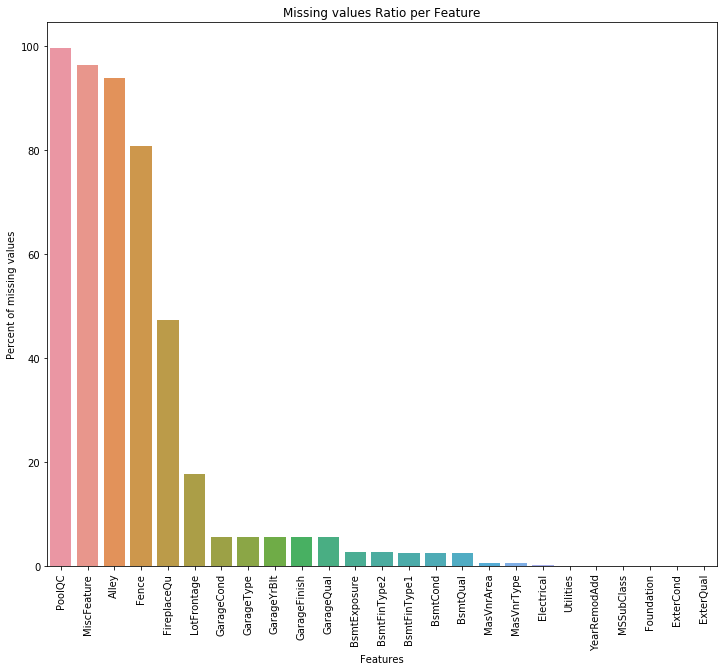

```python
f, ax = plt.subplots(figsize=(12, 10))
plt.title("Missing values Ratio per Feature")
plt.xlabel("Features")
plt.ylabel("Percent of missing values")
plt.xticks(rotation='90')
sns.barplot(x=missing_data.index, y=ratio);
```

```python
def transform_1_impute_missing(df):
    # Per the data description, the NA in the PoolQC column means the house did not have a pool. We can impute that with "None"
    df["PoolQC"] = df["PoolQC"].fillna("None")
    # MiscFeature. The description says that NA means No Misc Feature
    df["MiscFeature"] = df["MiscFeature"].fillna("None")
    # Alley
    df["Alley"] = df["Alley"].fillna("None")
    # Fence
    df["Fence"] = df["Fence"].fillna("None")
    # FireplaceQu
    df["FireplaceQu"] = df["FireplaceQu"].fillna("None")
    # LotFrontage: For this we cannot use None. Everyhouse "should" have front in the use.
    # Since houses are most probably similar in each neighborhoods, we can impute the missing values by the median of each
    # neighborhood.
    df["LotFrontage"] = df.groupby("Neighborhood")["LotFrontage"].transform(lambda x:
                                                                            x.fillna(x.median()))
    # GarageCond, GarageType, GarageYrBlt
    df[["GarageCond", "GarageType", "GarageQual", "GarageFinish"]] = df[["GarageCond",
                                                                         "GarageType",
                                                                         "GarageQual",
                                                                         "GarageFinish"]].fillna("None")
    # We will impute the following with 0 since they are quntatitive.
    df[["GarageArea", "GarageCars", "GarageYrBlt"]] = df[["GarageArea",
                                                          "GarageCars",
                                                          "GarageYrBlt"]].fillna(0)

    # The following numerical features are related to baseemnt and we can replace NaNs with 0 since
    # NaN means zero basement
    for col in ("BsmtFinSF1", "BsmtFinSF2", "BsmtUnfSF","TotalBsmtSF", "BsmtFullBath", "BsmtHalfBath"):
        df[col] = df[col].fillna(0)
    # The following categorical features are related to basement and we can replace the NAs with Non since NaN mean
    # no basement
    for col in ("BsmtQual", "BsmtCond", "BsmtExposure", "BsmtFinType1", "BsmtFinType2"):
        df[col] = df[col].fillna("None")
    #  MasVnrType: to None
    df["MasVnrType"] = df["MasVnrType"].fillna("None")
    # MasVnrType to 0   : Having NaN in the Veneer area means 0 veneer
    df["MasVnrArea"] = df["MasVnrArea"].fillna(0)
    # MSZonming: After looking at the zoning informationk, we can see that "RL" is the most common value.
    # We can use that to impute The missing zones.
    df["MSZoning"] = df["MSZoning"].fillna(df["MSZoning"].mode()[0])
    # Exterior1st: Impute with most common value:
    df["Exterior1st"] = df["Exterior1st"].fillna(df["Exterior1st"].mode()[0])
    # Exteriror2nd: Impute with most common value:
    df["Exterior2nd"] = df["Exterior2nd"].fillna(df["Exterior2nd"].mode()[0])
    # Utilities : Since most of the values in the dataframe for Utilities is "AllPub", we can drop
    # this feature without affecting our model. We will drop it later in the feature engineering phase
    # Fucntional: NA means typical
    df["Functional"] = df["Functional"].fillna("Typ")
    # Electrical : We can impute this with the most common value which is "SBrkr"
    df["Electrical"] = df["Electrical"].fillna(df["Electrical"].mode()[0])
    # Kitchen Qual : we can impute this with the most common value which is "TA"
    df["KitchenQual"] = df["KitchenQual"].fillna(df["KitchenQual"].mode()[0])
    # MSSubClass : Impute with None
    df["MSSubClass"] = df["MSSubClass"].fillna("None")
    # SaleType: Impute with the most common value which is "WD"
    df["SaleType"] = df["SaleType"].fillna(df["SaleType"].mode()[0])

    return df
```

```python
df_scaled = transform_1_impute_missing(df_scaled)
```

```python
# Double check to make sure all the missing values are imputed:
# Counting the missing values per feature and picking the top 25
missing_values = df_scaled.isnull().sum().sort_values(ascending=False)[:25]
# Calculating the missing ratio and picking the top 25
ratio = ((df_scaled.isnull().sum()/df_scaled.isnull().count())*100).sort_values(ascending=False)[:25]
missing_data = pd.concat([missing_values, ratio], axis=1, keys=['Total Missing', 'Percent'])
missing_data.head(5)
```

|  | Total Missing | Percent |
| --- | --- | --- |
| SalePrice | 0 | 0.0 |
| Heating | 0 | 0.0 |
| RoofStyle | 0 | 0.0 |
| RoofMatl | 0 | 0.0 |
| Exterior1st | 0 | 0.0 |

## Correlation

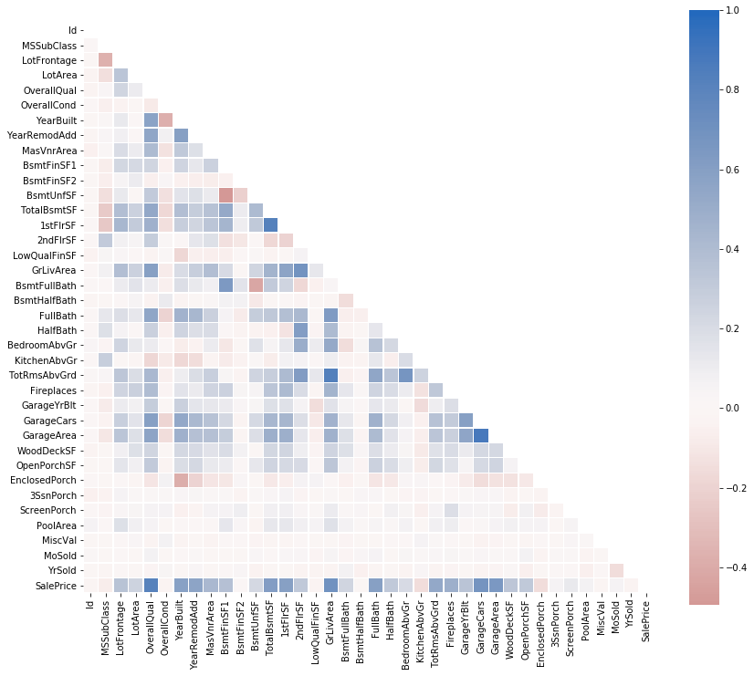

```python
#Using Pearson Correlation
#plt.figure(figsize=(12,10))
# Calculate the correlation on the entire dataframe
cor = df_scaled.corr()
# Create a mask to hight the cells above the diagonal line.
mask = np.triu(np.ones_like(cor, dtype=bool))
# Setting up the figure
f, ax = plt.subplots(figsize=(14, 12))
# Create a custom color pallete
cmap = cmap = sns.cm.vlag_r
# Draw the heatmap with the mask.
sns.heatmap(cor, annot=False, mask=mask, square=True, linewidths=.4,
            vmax=1, center=0, cmap=cmap);
plt.show();
```

In the following section, I want to define a function that helps us narrow down our heatmap to the top n highly correlated variables that we want to display.

```python
def draw_heatmap(df, y_variable, no_features):
    """ This Function takes three arguments;
        1. The dataframe that we want to draw the heatmap for
        2. The variable that we want to see the correlation of with other features for example the y-variable.
        3. The top_n. For example for top 10 variables, type 10."""
    # Calculate the correlation matrix
    cor = df.corr()
    # Get the columns for n largetst features
    columns = cor.nlargest(no_features, y_variable)[y_variable].index
    cm = np.corrcoef(df[columns].values.T)
    sns.set(font_scale=1)
    fig = plt.figure(num=None, figsize=(10, 10), dpi=80, facecolor='w', edgecolor='k')
    # Define the color pallet
    cmap = sns.cm.vlag_r
    heat_map = sns.heatmap(cm, cbar=True, annot=True, square=True, fmt=".2f", annot_kws={'size':12},
                      yticklabels=columns.values, xticklabels=columns.values,
                      linewidths=.2,vmax=1, center=0, cmap= cmap)
    return plt.show();
```

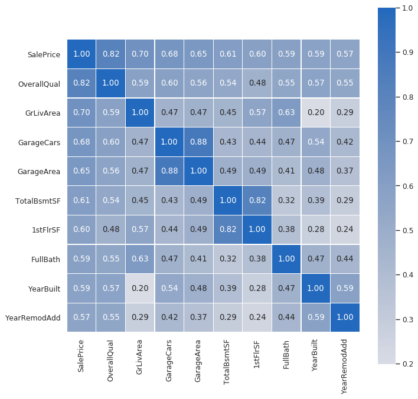

```python
# Let's see the top 10 features against "SalePrice"
draw_heatmap(df_scaled, "SalePrice", 10)
```

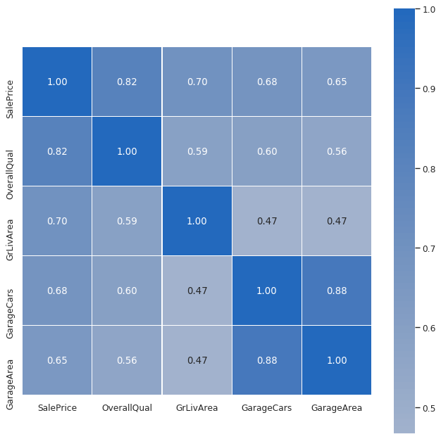

```python
# Let's see the top 5 variables:
draw_heatmap(df_scaled, "SalePrice", 5)
```

I want to check for multicollinearity between features that are about the same thigns for exmaple, Garage, or basement.

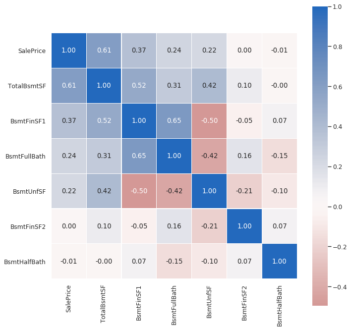

```python
basement_features =     ["BsmtFinSF1", "BsmtFinSF2", "BsmtUnfSF","TotalBsmtSF", "BsmtFullBath", "BsmtHalfBath",
                         "BsmtQual", "BsmtCond", "BsmtExposure", "BsmtFinType1", "BsmtFinType2", "SalePrice"]
bsmnt_df = df_scaled[basement_features]
draw_heatmap(bsmnt_df, "SalePrice", 10)
```

As we can see the features are somehow correlated, but I don't think they will affect the model. I am going to use the TotalBsmtSF later to create another feature and will drop it.

Let's check for the features of Garage:

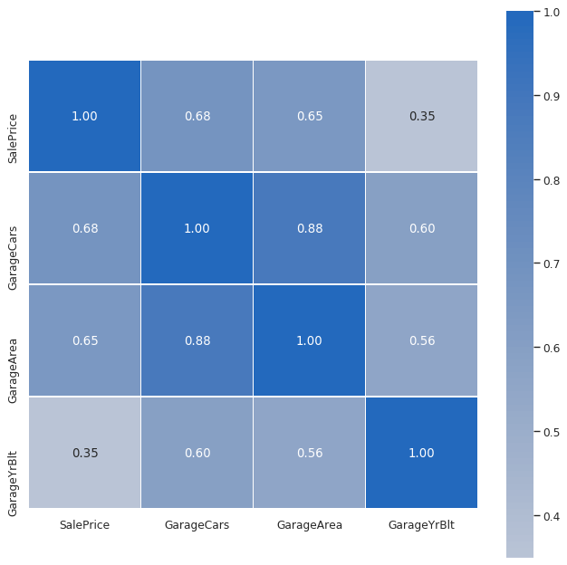

```python
garage_features = ["GarageCond","GarageType", "GarageQual","GarageFinish", "GarageArea","GarageCars","GarageYrBlt", "SalePrice"]
garage_df = df_scaled[garage_features]
draw_heatmap(garage_df, "SalePrice", 10)
```

```python
corr, _ = pearsonr(df_scaled["GarageArea"], df_scaled["GarageCars"])
print('Pearsons correlation: %.3f' % corr)
```

```
Pearsons correlation: 0.882
```

I am going to use the GarageArea in to create another variable and will drop it from the dataframe, so I don't have to worry about multicollinearity

## Feature Engineering:

In this section I am going to create some new features and maybe delete some features that won't affect our model:

```python
def transform_2_encode_data(df):
    """
    Since most of of our features are ordinal categorical, we cannot use one hot encodeing or Pandas' get_dummies function here.
    Instead, we are going to code them manualy so there is an order to the values.
    """
    # Convert the following columns  according to their dictionary.
    df['MSSubClass'] = df["MSSubClass"].replace(
     {20: 'SC20',30: 'SC30', 40: 'SC40', 45: 'SC45', 50: 'SC50', 60: 'SC60', 70: 'SC70', 75: 'SC75',
      80: 'SC80', 85: 'SC85', 90: 'SC90', 120: 'SC120', 150: 'SC150', 160: 'SC160', 180: 'SC180', 190: 'SC190'})
    #pd.get_dummies(df['MSSubClass'], prefix='MSSubClass')
    df = df.replace({'Street': {'Grvl': 0, 'Pave': 1},
                     'Alley': {'None':0, 'Grvl': 1, 'Pave': 2},
                     'ExterQual': {'Ex': 4, 'Gd': 3, 'TA': 2, 'Fa': 1,'Po': 0},
                     'ExterCond': {'Ex': 4, 'Gd': 3, 'TA': 2, 'Fa': 1,'Po': 0},
                     'BsmtExposure': {'Gd': 4, 'Av': 3, 'Mn': 2, 'No': 1,'None': 0},
                     'BsmtQual': {'Ex': 5, 'Gd': 4, 'TA': 3, 'Fa': 2,'Po': 1,'None': 0},
                     'BsmtCond': {'Ex': 5, 'Gd': 4, 'TA': 3, 'Fa': 2,'Po': 1,'None': 0},
                     'BsmtFinType1': {'None':0, 'Unf':1, 'LwQ':2, 'Rec':3, 'BLQ':4, 'ALQ':5, 'GLQ':6},
                     'BsmtFinType2': {'None':0, 'Unf':1, 'LwQ':2, 'Rec':3, 'BLQ':4, 'ALQ':5, 'GLQ':6},
                     'HeatingQC': {'Ex': 4, 'Gd': 3, 'TA': 2, 'Fa': 1,'Po': 0},
                     'CentralAir': {'N':0, 'Y':1},
                     'KitchenQual': {'Ex': 4, 'Gd': 3, 'TA': 2, 'Fa': 1, 'Po': 0},
                     'Functional': {'Typ':0,'Min1':1,'Min2':1,'Mod':2,'Maj1':3,'Maj2':4,'Sev':5,'Sal': 6},
                     'FireplaceQu': {'Ex': 5, 'Gd': 4, 'TA': 3, 'Fa': 2, 'Po': 1, 'None': 0},
                     'GarageQual': {'Ex': 5, 'Gd': 4, 'TA': 3, 'Fa': 2, 'Po': 1, 'None': 0},
                     'GarageCond': {'Ex': 5, 'Gd': 4, 'TA': 3, 'Fa': 2, 'Po': 1, 'None': 0},
                     'GarageFinish': {'Fin': 3, 'RFn':2, 'Unf':1, 'None':0},
                     'PoolQC': {'Ex': 4, 'Gd': 3, 'TA': 2, 'Fa': 1, 'None': 0},
                     'Fence': {'GdPrv': 2, 'GdWo': 2, 'MnPrv': 1, 'MnWw': 1, 'None': 0},
                     'HeatingQC': {'Ex': 4, 'Gd': 3, 'TA': 2, 'Fa': 1,'Po': 0},
                     'LotShape' : {'Reg': 3, 'IR1':2, 'IR2':1, 'IR3':0},
                     'LandSlope': {'Gtl': 2, 'Mod':1, 'Sev':0}
                      })
    # Convert the Neighborhoods to latitude and longtitude
    dict_neighbor = {
        'NAmes'  :{'lat': 42.045830,'lon': -93.620767},
        'CollgCr':{'lat': 42.018773,'lon': -93.685543},
        'OldTown':{'lat': 42.030152,'lon': -93.614628},
        'Edwards':{'lat': 42.021756,'lon': -93.670324},
        'Somerst':{'lat': 42.050913,'lon': -93.644629},
        'Gilbert':{'lat': 42.060214,'lon': -93.643179},
        'NridgHt':{'lat': 42.060357,'lon': -93.655263},
        'Sawyer' :{'lat': 42.034446,'lon': -93.666330},
        'NWAmes' :{'lat': 42.049381,'lon': -93.634993},
        'SawyerW':{'lat': 42.033494,'lon': -93.684085},
        'BrkSide':{'lat': 42.032422,'lon': -93.626037},
        'Crawfor':{'lat': 42.015189,'lon': -93.644250},
        'Mitchel':{'lat': 41.990123,'lon': -93.600964},
        'NoRidge':{'lat': 42.051748,'lon': -93.653524},
        'Timber' :{'lat': 41.998656,'lon': -93.652534},
        'IDOTRR' :{'lat': 42.022012,'lon': -93.622183},
        'ClearCr':{'lat': 42.060021,'lon': -93.629193},
        'StoneBr':{'lat': 42.060227,'lon': -93.633546},
        'SWISU'  :{'lat': 42.022646,'lon': -93.644853},
        'MeadowV':{'lat': 41.991846,'lon': -93.603460},
        'Blmngtn':{'lat': 42.059811,'lon': -93.638990},
        'BrDale' :{'lat': 42.052792,'lon': -93.628820},
        'Veenker':{'lat': 42.040898,'lon': -93.651502},
        'NPkVill':{'lat': 42.049912,'lon': -93.626546},
        'Blueste':{'lat': 42.010098,'lon': -93.647269}
        }
    df["Lat"] = df["Neighborhood"].map(lambda x: dict_neighbor[x]['lat'])
    df["lon"] = df["Neighborhood"].map(lambda x: dict_neighbor[x]['lon'])
    df.drop(["Neighborhood"], axis=1, inplace=True)

    # Cols that need to be encoded using LabelEncoder:
    df["OverallCond"] = df["OverallCond"].astype(int)
    df["ExterQual"] = df["ExterQual"].astype(int)
    df["KitchenQual"] = df["KitchenQual"].astype(int)
    df["Functional"] = df["Functional"].astype(int)


    cols = ('PavedDrive','OverallCond', 'YrSold', 'MSZoning', 'LandContour', 'Condition1',
       'Condition2', 'BldgType', 'HouseStyle', 'GarageType', 'LotConfig', 'Exterior1st', 'Exterior2nd', 'MasVnrType',
           'RoofStyle', 'RoofMatl', 'Foundation', 'Heating', 'Electrical', 'MiscFeature',
           'SaleType','SaleCondition' )

    for column in cols:
        label = LabelEncoder()
        label.fit(list(df[column].values))
        df[column] = label.transform(list(df[column].values))

    # Now that we have the list of ordinal categories encoded, we can use Panda's get_dummy function to
    # convert the rest to dummy variable.
    #df = pd.get_dummies(df)

    return df
```

```python
def transform_3_simplify_and_create_features(df):
    """ In the section, we are going to create create some new features from the existing features and then drop the
    features that we don't need anymore."""
    df = df.drop(["Id"], axis=1)

    df['HasPool'] = df['PoolArea'].apply(lambda x: 1 if x > 0 else 0)
    df['Has2ndFloor'] = df['2ndFlrSF'].apply(lambda x: 1 if x > 0 else 0)
    df['HasGarage'] = df['GarageArea'].apply(lambda x: 1 if x > 0 else 0)
    df['HasBsmt'] = df['TotalBsmtSF'].apply(lambda x: 1 if x > 0 else 0)
    df['HasFireplace'] = df['Fireplaces'].apply(lambda x: 1 if x > 0 else 0)

    df["MoSold"] = df["MoSold"].astype(str)
    df["YrSold"] = df["YrSold"].astype(str)

    # Create dummy variable for MoSold and MSSubClass variables.
    df = pd.concat([df, pd.get_dummies(df["MoSold"], prefix='MoSold')], axis=1)
    df = pd.concat([df, pd.get_dummies(df["MSSubClass"], prefix='MSSubClass')], axis=1)

    # Adding a column for the total squqre footage. We can calculate this by taking the sum of all possible areas
    # which could be the sum of total basement, 1st floor and 2nd floor areas
    df["TotalSqF"] = (df["TotalBsmtSF"] + df["1stFlrSF"] + df["2ndFlrSF"] +
                        df["GarageArea"] + df["BsmtFinSF1"] + df["BsmtFinSF2"] + df["PoolArea"])
    # Total number of bathrooms
    df["TotalBaths"] = (df["HalfBath"] + (0.5 * df["FullBath"]) +
                        df["BsmtFullBath"] + (0.5*df["BsmtHalfBath"]))

    # Total Porch Square Feet
    df['TotalPorchSF'] = (df["OpenPorchSF"] + df["3SsnPorch"] +
                              df["EnclosedPorch"] + df["ScreenPorch"] +
                              df["WoodDeckSF"])
    # Let's get the current year first
    current_year = int(datetime.now().strftime('%Y'))

    # House Age
    # Now let's subract the year built from the current year variable to caculate the age of the hosue
    df["HouseAge"] = current_year - df["YearBuilt"]

    # House Remodeling Age
    df["RemodAddAge"] = current_year - df["YearRemodAdd"]

    # Garage AGe
    df["GarageAge"] = current_year - df["GarageYrBlt"]


    df["SimplOverallQual"] = df.OverallQual.replace({1 : 1, 2 : 1, 3 : 1, 4 : 1, 5 : 1, 6 : 1,7 : 1, # Not Good
                                                     8 : 3, 9 : 3, 10 : 3 # good
                                                    })
    df["SimplOverallCond"] = df.OverallCond.replace({1 : 1, 2 : 1, 3 : 1, 4 : 1, 5 :1, 6 : 1, 7: 1,  # Not Good
                                                     8 : 2, 9 : 2, 10 : 2 # good
                                                    }).astype(int)
    df["SimplPoolQC"] = df.PoolQC.replace({1 : 1, 2 : 1, 3: 1, # Not Good
                                           4 : 2 # good
                                          }).astype(int)
    df["SimplGarageCond"] = df.GarageCond.replace({1 : 1, 2 : 1, 3 : 1, 4 : 1, # Not Good
                                                   5 : 2 # good
                                                  }).astype(int)
    df["SimplGarageQual"] = df.GarageQual.replace({1 : 1, 2 : 1, 3 : 1, 4 : 1, # Not Good
                                                   5 : 2 # good
                                                  }).astype(int)
    df["SimplFireplaceQu"] = df.FireplaceQu.replace({1 : 1, 2 : 1, 3 : 1, 4 : 1, # Not Good
                                                     5 : 2 # good
                                                    })
    df["SimplFireplaceQu"] = df.FireplaceQu.replace({1 : 1, 2 : 1, 3 : 1, 4 : 1, # Not Good
                                                     5 : 2 # good
                                                    }).astype(int)
    df["SimplFunctional"] = df.Functional.replace({1 : 1, 2 : 1, # bad
                                                   3 : 2, 4 : 2, # major
                                                   5 : 3, 6 : 3, 7 : 3, # minor
                                                   8 : 4 # typical
                                                  })
    df["SimplKitchenQual"] = df.KitchenQual.replace({1 : 1, 2 : 1, 3 : 1, 4 : 1, # Not Good
                                                     5 : 2 # good
                                                    })
    df["SimplHeatingQC"] = df.HeatingQC.replace({1 : 1, 2 : 1, 3 : 1, 4 : 1, # Not Good
                                                 5 : 2 # good
                                                })
    df["SimplBsmtFinType1"] = df.BsmtFinType1.replace({1 : 1, # unfinished
                                                       2 : 1, 3 : 1, # rec room
                                                       4 : 2, 5 : 2, 6 : 2 # living quarters
                                                      }).astype(int)
    df["SimplBsmtFinType2"] = df.BsmtFinType2.replace({1 : 1, # unfinished
                                                       2 : 1, 3 : 1, # rec room
                                                       4 : 2, 5 : 2, 6 : 2 # living quarters
                                                      })
    df["SimplBsmtCond"] = df.BsmtCond.replace({1 : 1, 2 : 1, 3 : 1, 4 : 1, # Not Good
                                               5 : 2 # good
                                              })
    df["SimplBsmtQual"] = df.BsmtQual.replace({1 : 1, 2 : 1, 3 : 1, 4 : 1, # Not Good
                                               5 : 2 # good
                                              })
    df["SimplExterCond"] = df.ExterCond.replace({1 : 1, 2 : 1, 3 : 1, 4 : 1, # Not Good
                                                 5 : 2 # good
                                                })
    df["SimplExterQual"] = df.ExterQual.replace({1 : 1, 2 : 1, 3 : 1, 4 : 1, # Not Good
                                                 5 : 2 # good
                                                })
    df["OverallQual-s2"] = df["OverallQual"] ** 2
    df["OverallQual-s3"] = df["OverallQual"] ** 3
    df["GrLivArea-2"] = df["GrLivArea"] ** 2
    df["GrLivArea-3"] = df["GrLivArea"] ** 3
    df["SimplOverallQual-s2"] = df["SimplOverallQual"] ** 2
    df["SimplOverallQual-s3"] = df["SimplOverallQual"] ** 3
    df["SimplOverallQual-Sq"] = np.sqrt(df["SimplOverallQual"])
    df["ExterQual-2"] = (df["ExterQual"]).astype(int) ** 2
    df["ExterQual-3"] = df["ExterQual"] ** 3
    df["ExterQual-Sq"] = np.sqrt((df["ExterQual"].astype(int)))
    df["GarageCars-2"] = df["GarageCars"] ** 2
    df["GarageCars-3"] = (df["GarageCars"] ** 3).astype(int)
    df["GarageCars-Sq"] = np.sqrt(df["GarageCars"])
    df["TotalBath-2"] = df["TotalBaths"] ** 2
    df["TotalBath-3"] = df["TotalBaths"] ** 3
    df["TotalBath-Sq"] = np.sqrt(df["TotalBaths"])
    df["KitchenQual-2"] = (df["KitchenQual"] ** 2).astype(int)
    df["KitchenQual-3"] = (df["KitchenQual"] ** 3).astype(int)

    #drop the columns used to generate other columns.
    df.drop(["TotalBsmtSF", "1stFlrSF", "2ndFlrSF", "GarageArea", "BsmtFinSF1",
             "BsmtFinSF2", "HalfBath", "FullBath", "BsmtFullBath", "BsmtHalfBath",
            "OpenPorchSF", "3SsnPorch", "EnclosedPorch", "ScreenPorch", "WoodDeckSF",
            "YearBuilt","YearRemodAdd", "GarageYrBlt", "YrSold", 'MoSold', 'MSSubClass', "Utilities"], axis=1, inplace=True)
    return df
```

## Transforming the data:

In this section, I am going to apply the functions that we created earlier to transform the train and test data and prepare them for our Machine Learning algorithms.

```python
# This helper function is going to help us apply the functions in order and return a prepared dataframe.
def full_transform(df):
    return transform_3_simplify_and_create_features(transform_2_encode_data(transform_1_impute_missing(df)))
```

```python
train_data = full_transform(train_df)
# Rescale the target variable
train_data["SalePrice"] = np.log1p(train_data["SalePrice"])
test_data = full_transform(test_df)
```

Let's check and make sure that both the training and testing data have the same elements.

```python
print("Columns from the train data that are not in test ", train_data.columns.difference(test_data.columns))
print("Columns from the test data that are not in train ", test_data.columns.difference(train_data.columns))
```

```
Columns from the train data that are not in test  Index(['SalePrice'], dtype='object')
Columns from the test data that are not in train  Index(['MSSubClass_SC150'], dtype='object')
```

```python
# We should drop that MSSubClass_SC150 column from test data:
test_data = test_data.drop(['MSSubClass_SC150'], axis=1)
```

```python
print("Columns from the train data that are not in test ", train_data.columns.difference(test_data.columns))
print("Columns from the test data that are not in train ", test_data.columns.difference(train_data.columns))
```

```
Columns from the train data that are not in test  Index(['SalePrice'], dtype='object')
Columns from the test data that are not in train  Index([], dtype='object')
```

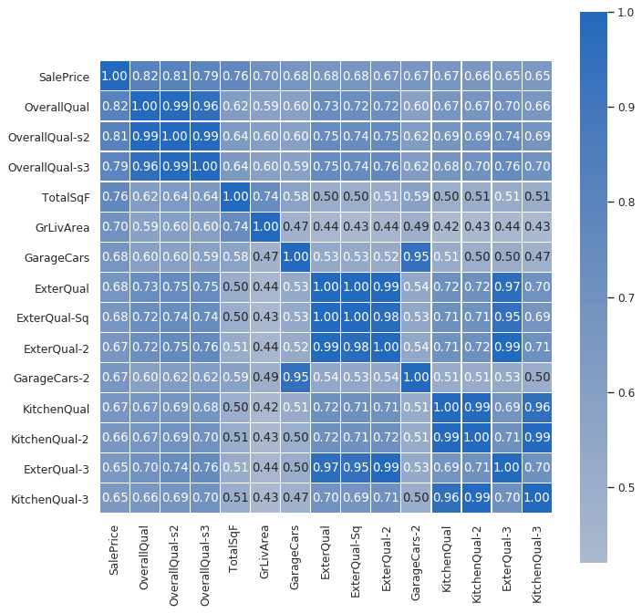

```python
# Let's check the heatmap for the transformed data.
draw_heatmap(train_data, "SalePrice", 15)
```

### Exploring the relationship between the highest correlated features and the SalePrice

Now that we know our top 5 highly correlated features, let's draw a scatter plot for some of the features to see how the data is distributed and if we could observe any outliers.

Since I am going to be displaying the relationship between several columns, I am going to define a function that will help us do that.

```python
def draw_scatter(df, x, y="SalePrice"):
    """ This fuction helps draw a scatter plot using Seaborn's functions.
    It takes three input arguements:
    1. The dataframe(data)
    2. our x variable that we want to display in our x axis
    3. y variable. The default column is 'SalePrice', however, we can change that
    to whatever column we want"""
    # Set the fiture size
    plt.figure(figsize=(12,10))
    # plot the variables
    sns.scatterplot(data=df, x=x, y=y, palette="deep").set_title("Scatter Plot for {} vs. {}".format(x, y))
```

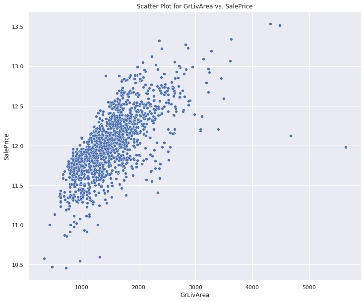

```python
# Let's look at the relationship between GrLivArea and the SalePrice
draw_scatter(df_scaled, "GrLivArea")
```

## Modeling

Now that we have our data prepared, let's start our modeling process.

### Libraries

Importing libraries that will be used:

```python
from sklearn.linear_model import ElasticNet, Lasso, Ridge, LinearRegression
from sklearn.kernel_ridge import KernelRidge
from sklearn.pipeline import make_pipeline
from sklearn.preprocessing import RobustScaler
from sklearn.model_selection import KFold, cross_val_score, train_test_split
from sklearn.metrics import mean_squared_error
from sklearn.model_selection import RandomizedSearchCV
from sklearn.feature_selection import RFECV
from sklearn.preprocessing import RobustScaler
from sklearn.metrics import make_scorer
from scipy.stats import uniform
from sklearn.linear_model import LinearRegression, RidgeCV, LassoCV, ElasticNetCV, SGDRegressor
from sklearn.datasets import make_regression
from sklearn.model_selection import train_test_split
from sklearn.feature_selection import SelectKBest
from sklearn.feature_selection import mutual_info_regression
from sklearn.linear_model import LinearRegression
from sklearn.metrics import mean_absolute_error
from sklearn.datasets import make_regression
from sklearn.model_selection import RepeatedKFold
from sklearn.feature_selection import SelectKBest
from sklearn.feature_selection import mutual_info_regression
from sklearn.linear_model import LinearRegression
from sklearn.pipeline import Pipeline
from sklearn.model_selection import GridSearchCV
from xgboost import XGBRegressor
from sklearn.ensemble import RandomForestRegressor,  GradientBoostingRegressor
```

### Preparing the data for the model:

```python
# Copying our transformed data
data = train_data.copy()
#Splitting the data into feature and target varaibles.
housing = data.drop("SalePrice", axis=1) # drop labels for training set
housing_labels = data["SalePrice"].copy()

# Prepare our training data into train test portions.
X_train, X_test, y_train, y_test = train_test_split(housing, housing_labels, test_size = 0.35,
                                                   random_state = 123)
```

# Feature Selection

Now that we have our data prepared, we should perform feature selection to reduce the number of features. We can see that we 130 features. Feature selection is going to help us improve performance and also reduce CPU runtime.

### Feature Selection Using XGBoost

```python
xgb = XGBRegressor()
xgb.fit(X_train, y_train)
imp = pd.DataFrame(xgb.feature_importances_ ,columns = ['Importance'],index = X_train.columns)
feature_importances = imp.sort_values(by='Importance',ascending=False)
feature_importances.head(32)
```

```
[18:11:32] WARNING: /home/conda/feedstock_root/build_artifacts/xgboost_1572314959925/work/src/objective/regression_obj.cu:152: reg:linear is now deprecated in favor of reg:squarederror.
```

|  | Importance |
| --- | --- |
| ExterQual | 0.174671 |
| KitchenQual | 0.122370 |
| GarageFinish | 0.118007 |
| TotalSqF | 0.074174 |
| OverallQual | 0.073914 |
| GarageType | 0.069226 |
| BsmtQual | 0.060538 |
| FireplaceQu | 0.044923 |
| GrLivArea | 0.036401 |
| GarageCars | 0.018663 |
| CentralAir | 0.013969 |
| TotalBaths | 0.013247 |
| RemodAddAge | 0.012055 |
| lon | 0.011845 |
| MSSubClass_SC30 | 0.011645 |
| GarageCond | 0.009565 |
| MSSubClass_SC190 | 0.009433 |
| Lat | 0.009193 |
| GarageQual | 0.008209 |
| OverallCond | 0.008081 |
| SaleCondition | 0.005756 |
| LotArea | 0.005577 |
| MSZoning | 0.005012 |
| HouseAge | 0.004693 |
| TotalPorchSF | 0.004523 |
| Functional | 0.004086 |
| Alley | 0.003887 |
| Fireplaces | 0.003760 |
| Condition1 | 0.003479 |
| GarageAge | 0.003335 |
| KitchenAbvGr | 0.003233 |
| LowQualFinSF | 0.003085 |

### Feature Importance Using Random Forest Regressor

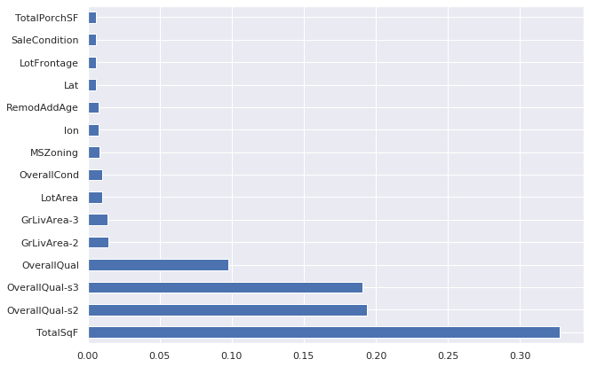

```python
rfr_model = RandomForestRegressor(max_depth=10)
rfr_model.fit(X_train, y_train)

# plot the 7 most important features
plt.figure(figsize=(10,7))
feat_importances = pd.Series(rfr_model.feature_importances_, index = X_train.columns)
feat_importances.nlargest(15).plot(kind='barh');
```

### Feature Importance using RFEC (Recursive feature elimination and cross-validated selection)

```python
# Define a function to calculate RMSE
def rmse(y_true, y_pred):
    return np.sqrt(np.mean((y_true-y_pred)**2))

# Define a function to calculate negative RMSE (as a score)
def nrmse(y_true, y_pred):
    return -1.0*rmse(y_true, y_pred)

neg_rmse = make_scorer(nrmse)

estimator = XGBRegressor()
selector = RFECV(estimator, cv = 3, n_jobs = -1, scoring = neg_rmse)
selector = selector.fit(X_train, y_train)

print("The number of selected features is: {}".format(selector.n_features_))

features_kept = X_train.columns.values[selector.support_]

X_train = X_train[features_kept]
X_test = X_test[features_kept]

features_kept
```

[output not shown]

```python
features_kept
```

```
array(['MSZoning', 'LotFrontage', 'LotArea', 'Condition1', 'OverallQual',
       'OverallCond', 'Exterior1st', 'ExterQual', 'Foundation',
       'BsmtQual', 'BsmtExposure', 'CentralAir', 'LowQualFinSF',
       'GrLivArea', 'KitchenQual', 'Functional', 'FireplaceQu',
       'GarageType', 'GarageFinish', 'GarageCars', 'GarageQual',
       'GarageCond', 'SaleCondition', 'Lat', 'lon', 'MSSubClass_SC30',
       'TotalSqF', 'TotalBaths', 'TotalPorchSF', 'HouseAge',
       'RemodAddAge', 'GarageAge'], dtype=object)
```

```python
# Features Kept
feature_kept = ['MSZoning', 'LotFrontage', 'LotArea', 'Condition1', 'OverallQual', 'OverallCond',
                'Exterior1st', 'ExterQual', 'Foundation', 'BsmtQual', 'BsmtExposure', 'CentralAir',
                'LowQualFinSF', 'GrLivArea', 'KitchenQual', 'Functional', 'FireplaceQu', 'GarageType',
                'GarageFinish', 'GarageCars', 'GarageQual', 'GarageCond', 'SaleCondition', 'Lat', 'lon',
                'MSSubClass_SC30', 'TotalSqF', 'TotalBaths', 'TotalPorchSF', 'HouseAge', 'RemodAddAge', 'GarageAge']
```

```python
X_train1 = X_train[feature_kept]
X_test1 =  X_test[feature_kept]
```

# Building and Training the Models

First, I am going to run a regular Gridsearch

#### Using Basic Regression Models

```python
def test_models(models, data, iterations = 100):
    results = {}
    for i in models:
        r2_train = []
        r2_test = []
        for j in range(iterations):
            X_train, X_test, y_train, y_test = train_test_split(data[feature_kept],
                                                                data["SalePrice"],
                                                                test_size= 0.2)
            r2_test.append(mean_squared_error(y_test,
                                            models[i].fit(X_train,
                                                         y_train).predict(X_test)))
            r2_train.append(mean_squared_error(y_train,
                                             models[i].fit(X_train,
                                                          y_train).predict(X_train)))
        results[i] = [np.mean(r2_train), np.mean(r2_test)]
    return pd.DataFrame(results)
```

```python
# Parameters for Lasso and Ridge Regression Models.
lasso_params = {'alpha':[5e-05, 0.0001, 0.0002, 0.0003, 0.0004, 0.0005, 0.0006, 0.0007, 0.0008, 0.0009, 0.01]}
ridge_params = {'alpha':[14.5, 14.6, 14.7, 14.8, 14.9, 15, 15.1, 15.2, 15.3, 15.4, 15.5, 16, 20, 30, 31, 32, 35, 38, 40, 50]}

# Defining our Models and fitting them on the training data.
models2 = {'OLS': LinearRegression(),
           'Lasso': GridSearchCV(Lasso(),
                               param_grid=lasso_params).fit(X_train1, y_train).best_estimator_,
           'Ridge': GridSearchCV(Ridge(),
                               param_grid=ridge_params).fit(X_train1, y_train).best_estimator_,}
```

```python
test_models(models2, train_data)
```

|  | OLS | Lasso | Ridge |
| --- | --- | --- | --- |
| 0 | 0.019607 | 0.019558 | 0.020185 |
| 1 | 0.024889 | 0.025196 | 0.023315 |

#### Using Cross Validation and Stacking Models

```python
from sklearn.svm import SVR
from lightgbm import  LGBMRegressor
from mlxtend.regressor import StackingCVRegressor

kfolds = KFold(n_splits=10, shuffle=True, random_state=42)

def rmsle(y_test, y_pred):
    return np.sqrt(mean_squared_error(y_test, y_pred))

def cv_rmse(model, X=X_train):
    rmse = np.sqrt(-cross_val_score(model, X_train1, y_train, scoring="neg_mean_squared_error", cv=kfolds))
    return (rmse)


alphas_alt = [14.5, 14.6, 14.7, 14.8, 14.9, 15, 15.1, 15.2, 15.3, 15.4, 15.5, 16, 20, 30, 40, 50]
alphas2 = [5e-05, 0.0001, 0.0002, 0.0003, 0.0004, 0.0005, 0.0006, 0.0007, 0.0008, 0.0009, 0.01]
e_alphas = [0.0001, 0.0002, 0.0003, 0.0004, 0.0005, 0.0006, 0.0007]
e_l1ratio = [0.8, 0.85, 0.9, 0.95, 0.99, 1]

ols = make_pipeline(RobustScaler(), LinearRegression())
ridge = make_pipeline(RobustScaler(), RidgeCV(alphas=alphas_alt, cv=kfolds))
lasso = make_pipeline(RobustScaler(), LassoCV(max_iter=1e7, alphas=alphas2, random_state=42, cv=kfolds))
elasticnet = make_pipeline(RobustScaler(), ElasticNetCV(max_iter=1e7, alphas=e_alphas, cv=kfolds, l1_ratio=e_l1ratio))
svr = make_pipeline(RobustScaler(), SVR(C= 20, epsilon= 0.008, gamma=0.0003,))
gbr = GradientBoostingRegressor(n_estimators=3000, learning_rate=0.05, max_depth=4, max_features='sqrt',
                                min_samples_leaf=15, min_samples_split=10, loss='huber', random_state =42)

lightgbm = LGBMRegressor(objective='regression',
                                       num_leaves=4,
                                       learning_rate=0.01,
                                       n_estimators=5000,
                                       max_bin=200,
                                       bagging_fraction=0.75,
                                       bagging_freq=5,
                                       bagging_seed=7,
                                       feature_fraction=0.2,
                                       feature_fraction_seed=7,
                                       verbose=-1,
                                       )
xgboost = XGBRegressor(learning_rate=0.01,n_estimators=3460,
                                     max_depth=3, min_child_weight=0,
                                     gamma=0, subsample=0.7,
                                     colsample_bytree=0.7,
                                     objective='reg:linear', nthread=-1,
                                     scale_pos_weight=1, seed=27,
                                     reg_alpha=0.00006)

stack_gen = StackingCVRegressor(regressors=(ols, ridge, lasso, elasticnet, gbr, xgboost, lightgbm),
                                meta_regressor=xgboost,
                                use_features_in_secondary=True)
```

```python
score = cv_rmse(ols)
print("OLS: {:.4f} ({:.4f})\n".format(score.mean(), score.std()), datetime.now(), )
```

```
OLS: 0.1548 (0.0599)
 2020-09-27 00:02:12.862336
```

```python
score = cv_rmse(ridge)
print("RIDGE: {:.4f} ({:.4f})\n".format(score.mean(), score.std()), datetime.now(), )
```

```
RIDGE: 0.1533 (0.0580)
 2020-09-26 23:04:07.360220
```

```python
score = cv_rmse(lasso)
print("LASSO: {:.4f} ({:.4f})\n".format(score.mean(), score.std()), datetime.now(), )
```

```
LASSO: 0.1551 (0.0607)
 2020-09-26 23:04:10.829679
```

```python
score = cv_rmse(elasticnet)
print("elastic net: {:.4f} ({:.4f})\n".format(score.mean(), score.std()), datetime.now(), )
```

```
elastic net: 0.1550 (0.0604)
 2020-09-26 23:04:14.699625
```

```python
score = cv_rmse(svr)
print("SVR: {:.4f} ({:.4f})\n".format(score.mean(), score.std()), datetime.now(), )
```

```
SVR: 0.1592 (0.0509)
 2020-09-26 23:04:16.601151
```

```python
score = cv_rmse(lightgbm)
print("lightgbm: {:.4f} ({:.4f})\n".format(score.mean(), score.std()), datetime.now(), )
```

[output not shown]

```python
score = cv_rmse(gbr)
print("gbr: {:.4f} ({:.4f})\n".format(score.mean(), score.std()), datetime.now(), )
```

```
gbr: 0.1240 (0.0159)
 2020-09-26 23:05:23.384815
```

```python
score = cv_rmse(xgboost)
print("xgboost: {:.4f} ({:.4f})\n".format(score.mean(), score.std()), datetime.now(), )
```

```
xgboost: 0.1225 (0.0198)
 2020-09-26 23:06:58.900403
```

```python
def blend_models_train(X, y):
    stack_gen_model = stack_gen.fit(np.array(X), np.array(y))
    ols_model = ols.fit(X, y)
    elastic_model = elasticnet.fit(X, y)
    lasso_model = lasso.fit(X, y)
    ridge_model = ridge.fit(X, y)
    svr_model = svr.fit(X, y)
    gbr_model = gbr.fit(X, y)
    xgb_model = xgboost.fit(X, y)
    lgb_model = lightgbm.fit(X, y)
    return stack_gen_model, ols_model, elastic_model, lasso_model, ridge_model, svr_model, gbr_model, xgb_model, lgb_model
```

```python
def blend_models_predict(y):
    # Here, we are going to weigth each model based on their performance during the cross validation phase
    return ((0.05 * elastic_model.predict(y)) + \
            (0.05 * lasso_model.predict(y)) + \
            (0.05 * ols_model.predict(y)) + \
            (0.1 * ridge_model.predict(y)) + \
            (0.1 * svr_model.predict(y)) + \
            (0.1 * gbr_model.predict(y)) + \
            (0.15 * xgb_model.predict(y)) + \
            (0.1 * lgb_model.predict(y)) + \
            (0.30 * stack_gen_model.predict(np.array(y))))
```

## Using the reduced features.

```python
(stack_gen_model, ols_model, elastic_model, lasso_model,
 ridge_model, svr_model, gbr_model, xgb_model, lgb_model) = blend_models_train(X_train1, y_train)
```

[output not shown]

```python
print('RMSLE score on train data:')
print(rmsle(y_test, blend_models_predict(X_test1)))
```

```
RMSLE score on train data:
0.12199268649690792
```

## Using all the features.

```python
from sklearn.svm import SVR
from lightgbm import  LGBMRegressor
from mlxtend.regressor import StackingCVRegressor

kfolds = KFold(n_splits=10, shuffle=True, random_state=42)

def rmsle(y_test, y_pred):
    return np.sqrt(mean_squared_error(y_test, y_pred))

def cv_rmse(model, X=X_train):
    rmse = np.sqrt(-cross_val_score(model, X_train, y_train, scoring="neg_mean_squared_error", cv=kfolds))
    return (rmse)


alphas_alt = [14.5, 14.6, 14.7, 14.8, 14.9, 15, 15.1, 15.2, 15.3, 15.4, 15.5, 16, 20, 30, 40, 50]
alphas2 = [5e-05, 0.0001, 0.0002, 0.0003, 0.0004, 0.0005, 0.0006, 0.0007, 0.0008, 0.0009, 0.01]
e_alphas = [0.0001, 0.0002, 0.0003, 0.0004, 0.0005, 0.0006, 0.0007]
e_l1ratio = [0.8, 0.85, 0.9, 0.95, 0.99, 1]

ols = make_pipeline(RobustScaler(), LinearRegression())
ridge = make_pipeline(RobustScaler(), RidgeCV(alphas=alphas_alt, cv=kfolds))
lasso = make_pipeline(RobustScaler(), LassoCV(max_iter=1e7, alphas=alphas2, random_state=42, cv=kfolds))
elasticnet = make_pipeline(RobustScaler(), ElasticNetCV(max_iter=1e7, alphas=e_alphas, cv=kfolds, l1_ratio=e_l1ratio))
svr = make_pipeline(RobustScaler(), SVR(C= 20, epsilon= 0.008, gamma=0.0003,))
gbr = GradientBoostingRegressor(n_estimators=3000, learning_rate=0.05, max_depth=4, max_features='sqrt',
                                min_samples_leaf=15, min_samples_split=10, loss='huber', random_state =42)

lightgbm = LGBMRegressor(objective='regression',
                                       num_leaves=4,
                                       learning_rate=0.01,
                                       n_estimators=5000,
                                       max_bin=200,
                                       bagging_fraction=0.75,
                                       bagging_freq=5,
                                       bagging_seed=7,
                                       feature_fraction=0.2,
                                       feature_fraction_seed=7,
                                       verbose=-1,
                                       )
xgboost = XGBRegressor(learning_rate=0.01,n_estimators=3460,
                                     max_depth=3, min_child_weight=0,
                                     gamma=0, subsample=0.7,
                                     colsample_bytree=0.7,
                                     objective='reg:linear', nthread=-1,
                                     scale_pos_weight=1, seed=27,
                                     reg_alpha=0.00006)

stack_gen = StackingCVRegressor(regressors=(ols, ridge, lasso, elasticnet, gbr, xgboost, lightgbm),
                                meta_regressor=xgboost,
                                use_features_in_secondary=True)
```

```python
(stack_gen_model, ols_model, elastic_model, lasso_model,
 ridge_model, svr_model, gbr_model, xgb_model, lgb_model) = blend_models_train(X_train, y_train)
```

[output not shown]

```python
print('RMSLE score on train data:')
print(rmsle(y_test, blend_models_predict(X_test)))
```

```
RMSLE score on train data:
0.12260349980970268
```

## Make Predictions and Submit

```python
# Make Prediction
predictions = blend_models_predict(test_data[feature_kept])
```

```python
submission = pd.DataFrame()
submission['Id'] = test_df['Id']
submission['SalePrice'] = np.expm1(predictions)
```

```python
submission
```

|  | Id | SalePrice |
| --- | --- | --- |
| 0 | 1461 | 125729.175784 |
| 1 | 1462 | 160650.578814 |
| 2 | 1463 | 189592.531168 |
| 3 | 1464 | 200040.687032 |
| 4 | 1465 | 186598.298786 |
| ... | ... | ... |
| 1454 | 2915 | 88231.559493 |
| 1455 | 2916 | 86288.093899 |
| 1456 | 2917 | 148240.122382 |
| 1457 | 2918 | 111424.548553 |
| 1458 | 2919 | 224435.260477 |

1459 rows × 2 columns

```python
submission.to_csv("data/submission.csv", index=False)
```

## Using gridsearch to find the optimal number of features

```python
# define the evaluation method
cv = RepeatedKFold(n_splits=10, n_repeats=3, random_state=1)
# define the pipeline to evaluate
model = LinearRegression()
fs = SelectKBest(score_func=mutual_info_regression)
pipeline = Pipeline(steps=[('sel',fs), ('lr', model)])
# define the grid
grid = dict()
grid['sel__k'] = [i for i in range(X_train.shape[1]-100, X_train.shape[1]+1)]
# define the grid search
#search = GridSearchCV(pipeline, grid, scoring='neg_mean_squared_error', n_jobs=-1, cv=cv)
search = GridSearchCV(pipeline, grid, scoring=rmse_score, n_jobs=-1, cv=cv)
# perform the search
results = search.fit(X_train, y_train)
# summarize best
print('Best MAE: %.3f' % results.best_score_)
print('Best Config: %s' % results.best_params_)
# summarize all
means = results.cv_results_['mean_test_score']
params = results.cv_results_['params']
for mean, param in zip(means, params):
    print(">%.3f with: %r" % (mean, param))
```

```
Best MAE: -0.152
Best Config: {'sel__k': 95}
>-0.166 with: {'sel__k': 29}
>-0.166 with: {'sel__k': 30}
>-0.166 with: {'sel__k': 31}
>-0.166 with: {'sel__k': 32}
>-0.165 with: {'sel__k': 33}
>-0.165 with: {'sel__k': 34}
>-0.165 with: {'sel__k': 35}
>-0.164 with: {'sel__k': 36}
>-0.163 with: {'sel__k': 37}
>-0.163 with: {'sel__k': 38}
>-0.162 with: {'sel__k': 39}
>-0.162 with: {'sel__k': 40}
>-0.162 with: {'sel__k': 41}
>-0.161 with: {'sel__k': 42}
>-0.161 with: {'sel__k': 43}
>-0.161 with: {'sel__k': 44}
>-0.162 with: {'sel__k': 45}
>-0.161 with: {'sel__k': 46}
>-0.161 with: {'sel__k': 47}
>-0.161 with: {'sel__k': 48}
>-0.160 with: {'sel__k': 49}
>-0.160 with: {'sel__k': 50}
>-0.158 with: {'sel__k': 51}
>-0.158 with: {'sel__k': 52}
>-0.156 with: {'sel__k': 53}
>-0.156 with: {'sel__k': 54}
>-0.155 with: {'sel__k': 55}
>-0.156 with: {'sel__k': 56}
>-0.155 with: {'sel__k': 57}
>-0.156 with: {'sel__k': 58}
>-0.155 with: {'sel__k': 59}
>-0.157 with: {'sel__k': 60}
>-0.156 with: {'sel__k': 61}
>-0.156 with: {'sel__k': 62}
>-0.156 with: {'sel__k': 63}
>-0.157 with: {'sel__k': 64}
>-0.156 with: {'sel__k': 65}
>-0.155 with: {'sel__k': 66}
```

[output cut: 48 more lines]

```
>-0.179 with: {'sel__k': 115}
>-0.176 with: {'sel__k': 116}
>-0.171 with: {'sel__k': 117}
>-0.197 with: {'sel__k': 118}
>-0.168 with: {'sel__k': 119}
>-0.190 with: {'sel__k': 120}
>-0.197 with: {'sel__k': 121}
>-0.169 with: {'sel__k': 122}
>-0.176 with: {'sel__k': 123}
>-0.189 with: {'sel__k': 124}
>-0.208 with: {'sel__k': 125}
>-0.206 with: {'sel__k': 126}
>-0.205 with: {'sel__k': 127}
>-0.206 with: {'sel__k': 128}
>-0.206 with: {'sel__k': 129}
```